# Görselleştirme Teknikleri Projesi

Ataman Önol ÜK

2024-07-14

# UYKU BOZUKLUĞU VERİSİNİN GÖRSELLEŞTİRİLMESİ

```r
library(readr)
sleep <- read.csv("C:/Users/atama/Downloads/Sleep.csv", header= TRUE, sep=",")
```

```r
str(sleep)
```

```
## 'data.frame':    374 obs. of  13 variables:
##  $ Person.ID              : int  1 2 3 4 5 6 7 8 9 10 ...
##  $ Gender                 : chr  "Male" "Male" "Male" "Male" ...
##  $ Age                    : int  27 28 28 28 28 28 29 29 29 29 ...
##  $ Occupation             : chr  "Software Engineer" "Doctor" "Doctor" "Sales Representative" ...
##  $ Sleep.Duration         : num  6.1 6.2 6.2 5.9 5.9 5.9 6.3 7.8 7.8 7.8 ...
##  $ Quality.of.Sleep       : int  6 6 6 4 4 4 6 7 7 7 ...
##  $ Physical.Activity.Level: int  42 60 60 30 30 30 40 75 75 75 ...
##  $ Stress.Level           : int  6 8 8 8 8 8 7 6 6 6 ...
##  $ BMI.Category           : chr  "Overweight" "Normal" "Normal" "Obese" ...
##  $ Blood.Pressure         : chr  "126/83" "125/80" "125/80" "140/90" ...
##  $ Heart.Rate             : int  77 75 75 85 85 85 82 70 70 70 ...
##  $ Daily.Steps            : int  4200 10000 10000 3000 3000 3000 3500 8000 8000 8000 ...
##  $ Sleep.Disorder         : chr  "None" "None" "None" "Sleep Apnea" ...
```

```r
sleep$Sleep.Disorder <- factor(sleep$Sleep.Disorder, levels=c("None","Sleep Apnea", "Insomnia"))
sleep$Gender <- factor(sleep$Gender, levels=c("Female","Male"))
sleep$BMI.Category <- factor(sleep$BMI.Category, levels=c("Normal","Obese","Overweight","Normal Weight"))
sleep$Quality.of.Sleep <- factor(sleep$Quality.of.Sleep, levels = 1:10, ordered=TRUE)
sleep$Stress.Level<- factor(sleep$Stress.Level, levels = 1:10, ordered=TRUE)
```

```r
levels(sleep$BMI.Category)[levels(sleep$BMI.Category) == "Normal Weight"] <- "Normal"
levels(sleep$BMI.Category)
```

```
## [1] "Normal"     "Obese"      "Overweight"
```

Yukarıdaki kodlar yardımı ile veri seti R’a tanıtıldı. Veri seti linki ise aşağıdadır:

https://www.kaggle.com/datasets/uom190346a/sleep-health-and-lifestyle-dataset

## Stacked Bar Plot

```r
library(ggpubr)
library(dplyr)
```

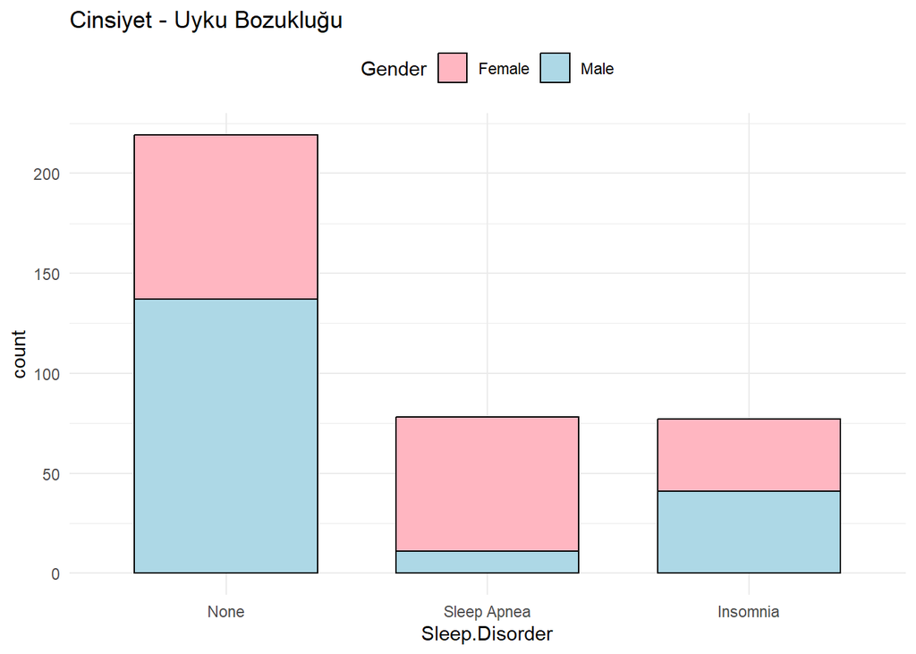

```r
freq_sd <- sleep %>%
  count(Gender, Sleep.Disorder) %>%
  rename(count = n)
ggbarplot(freq_sd, x = "Sleep.Disorder", y = "count",
          fill = "Gender", palette = c("Male" = "lightblue", "Female" = "lightpink"),
          title = "Cinsiyet - Uyku Bozukluğu",
          legend.title = "Gender") +
  theme_minimal() +
  theme(legend.position = "top")
```

Bu grafik uyku bozukluklarındaki cinsiyet dağılımını göstermek için yapıldı.

## Balloon Plot

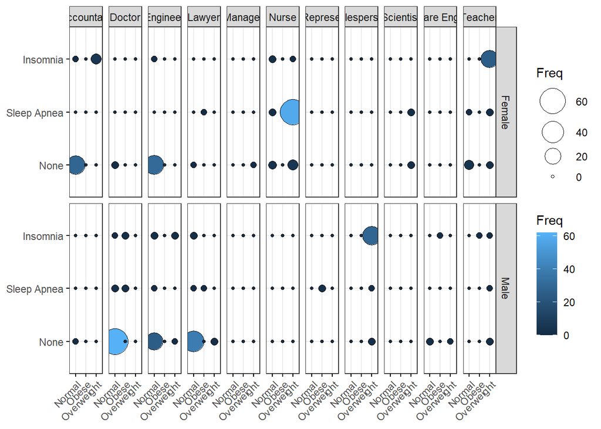

```r
balon <- xtabs(~ Sleep.Disorder+BMI.Category+Gender+Occupation, data=sleep)
balon_df <- as.data.frame(ftable(balon))
library(ggpubr)
ggballoonplot(
  balon_df, x = "BMI.Category", y = "Sleep.Disorder",
  size = "Freq", fill = "Freq",
  facet.by = c("Gender","Occupation"),
  ggtheme = theme_bw())
```

Elde edilen balon grafiğinde her bir balon, veri çerçevesindeki belirli bir kombinasyonu göstermektedir. Balonların boyutu frekansı temsil ederken, renkler de frekansın bir göstergesi olarak kabul edilmektedir.

- Kadınlar için en yüksek frekansın aşırı kilolu, uyku apnesine sahip ve mesleği hemşire olan bireylerde,
- Erkekler için en yüksek frekansın normal kilolu, uyku rahatsızlığı olmayan ve mesleği doktor olan bireylerde olduğu söylenebilir.

## Pie Chart

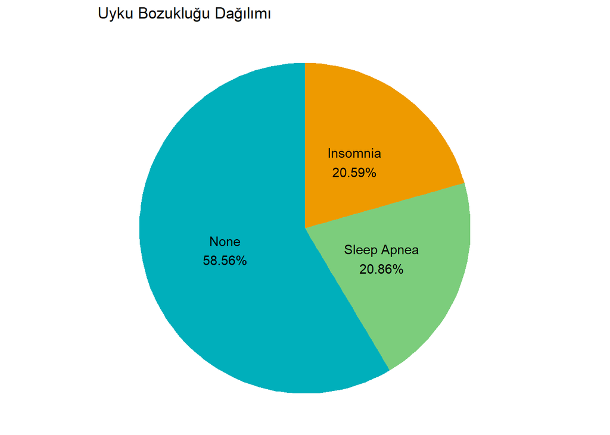

```r
library(ggplot2)

cross <- as.data.frame(prop.table(table(sleep$Sleep.Disorder)))
colnames(cross) <- c("Sleep.Disorder", "Freq")

colors <- c("#00AFBB", "palegreen3", "orange2")
cross$label <- paste0(cross$Sleep.Disorder, "\n", scales::percent(cross$Freq))

ggplot(cross, aes(x = "", y = Freq, fill = Sleep.Disorder)) +
  geom_bar(width = 1, stat = "identity") +
  coord_polar(theta = "y") +
  scale_fill_manual(values = setNames(colors, unique(cross$Sleep.Disorder))) +
  labs(title = "Uyku Bozukluğu Dağılımı", fill = "Sleep Disorder") +
  theme_void() +
  theme(legend.position = "none") +
  geom_text(aes(label = label), position = position_stack(vjust = 0.5))
```

Bu grafik uyku bozukluklarının dağılımlarını yüzdelik olarak göstermek için oluşturuldu.

- Pasta grafiğinde en büyük yüzdeliği % 58.56 ile “None” grubu oluşturmaktadır. Daha sonrasında % 20.86 ile “Sleep Apnea” ve %20.59 ile “Insomnia” grubu oluşturur.

## Histogram

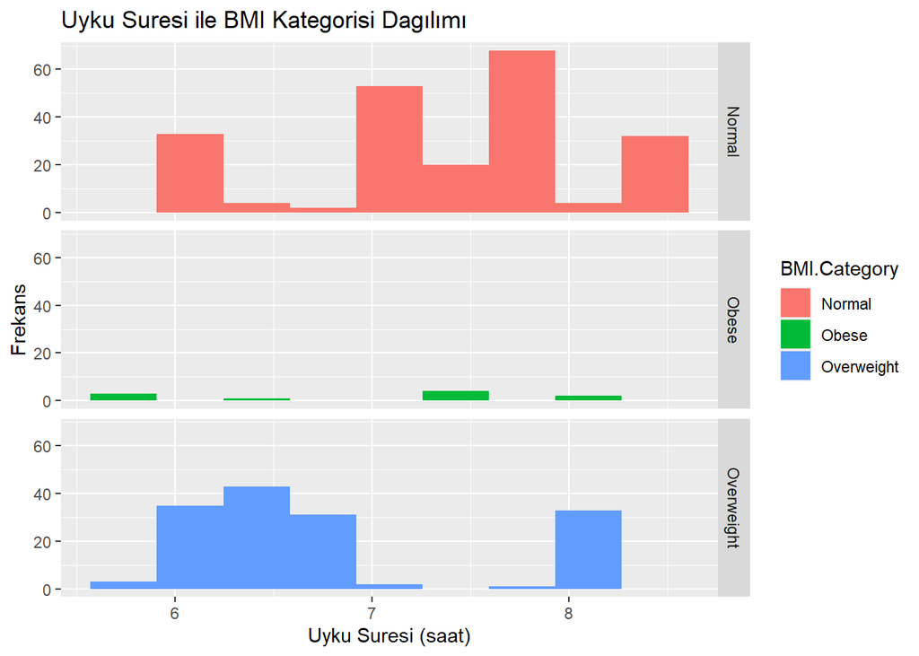

```r
k <- ceiling((log(2*nrow(sleep)))+1)
genislik <- max(sleep$Sleep.Duration)-min(sleep$Sleep.Duration)
binw <- genislik/k
library(ggplot2)
ggplot(sleep,aes(Sleep.Duration,fill=BMI.Category))+
  geom_histogram(binwidth=binw)+
  labs(title = "Uyku Suresi ile BMI Kategorisi Dagılımı",
       x = "Uyku Suresi (saat)",
       y = "Frekans") +
  facet_grid(BMI.Category~.)
```

BMI kategorisine bağlı olarak uyku sürelerinin ne kadar fark yaratabileceği incelendi.

- Normal kilolu bireyler için uyku sürelerine ilişkin histogram grafiğinin dağılımının sola çarpık olduğunu, dağılımın geniş ve birden fazla tepe noktasına sahipliği, daha fazla çeşitlilik olduğunu göstermektedir.
- Aşırı kilolu bireyler için uyku süresinin genel olarak 6 ile 7 saat arasında dağıldığı görülmektedir. Ancak 8 saat ve üzeri uyuyan ayrı bir grubun bu kategoride farklı bir küme oluşturduğunu söylemek de mümkündür.

## Scatterplot Matrix

```r
korelasyon <- sleep[,c(5,7,3)]

cor(korelasyon)
```

```
##                         Sleep.Duration Physical.Activity.Level       Age
## Sleep.Duration               1.0000000               0.2123603 0.3447094
## Physical.Activity.Level      0.2123603               1.0000000 0.1789927
## Age                          0.3447094               0.1789927 1.0000000
```

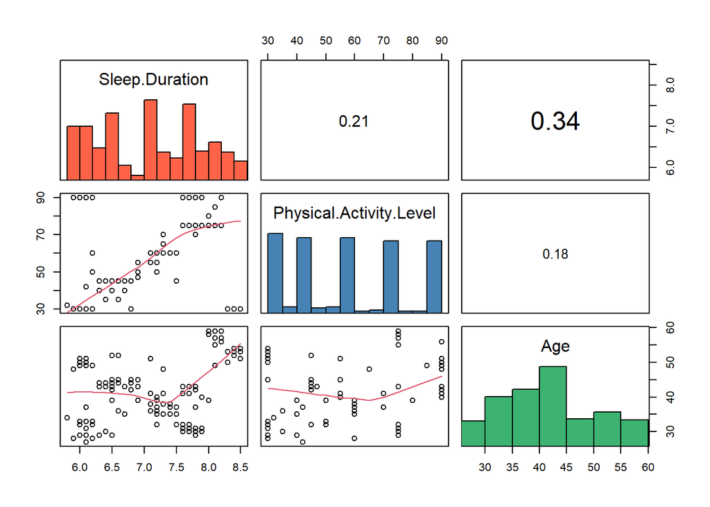

```r
panel.cor <- function(x, y, digits=2, prefix="", cex.cor) {
  usr <- par("usr"); on.exit(par(usr))
  par(usr=c(0,1,0,1))
  r = cor(x, y)
  txt <- format(c(r, 0.123456789), digits=digits)[1]
  txt <- paste(prefix, txt, sep="")
  if (missing(cex.cor)) cex <- 0.8/strwidth(txt)
  text(0.5, 0.5, txt, cex=cex*abs(r))
}

panel.hist <- function(x, col = "#F08080", ...) {
  usr <- par("usr"); on.exit(par(usr))
  par(usr = c(usr[1:2], 0, 1.5))
  h <- hist(x, plot = FALSE)
  breaks <- h$breaks; nB <- length(breaks)
  y <- h$counts; y <- y / max(y)
  rect(breaks[-nB], 0, breaks[-1], y, col = col, ...)
}

pairs(korelasyon,
      diag.panel = function(x, ...) {
        if (identical(x, korelasyon[, 1])) {
          panel.hist(x, col = "#FF6347", ...)
        } else if (identical(x, korelasyon[, 2])) {
          panel.hist(x, col = "#4682B4", ...)
        } else if (identical(x, korelasyon[, 3])) {
          panel.hist(x, col = "#3CB371", ...)
        }
      },
      lower.panel = panel.smooth,
      upper.panel = panel.cor)
```

Uyku süresi, fiziksel aktivite ve yaş değişkenleri için saçılım grafiği, korelasyon katsayıları ve yoğunluk grafikleri incelenmek için elde edildi.

- Korelasyon katsayılarına bakıldığında üç değişkenin de pozitif ilişkili olduğu söylenebilir.
- Histogramlar incelendiğinde fiziksel aktivite seviyelerinin beş kümeye ayrıldığı görülmektedir. Yaş değişkeni neredeyse normal dağılmakta ve uyku süresi için oluşturulan grafik, çift tepe noktasına sahip olduğundan iki ayrı uyku süresi grubunun olduğu söylenebilir.
- Saçılım grafikleri incelendiğinde uyku süresi ve fiziksel aktivite seviyesi arasında düşük bir pozitif ilişkinin olması, daha fazla fiziksel aktivitenin daha uzun uyku süreleri ile ilişkilendirilebileceğini gösterir.

## Jittered Dot Plot

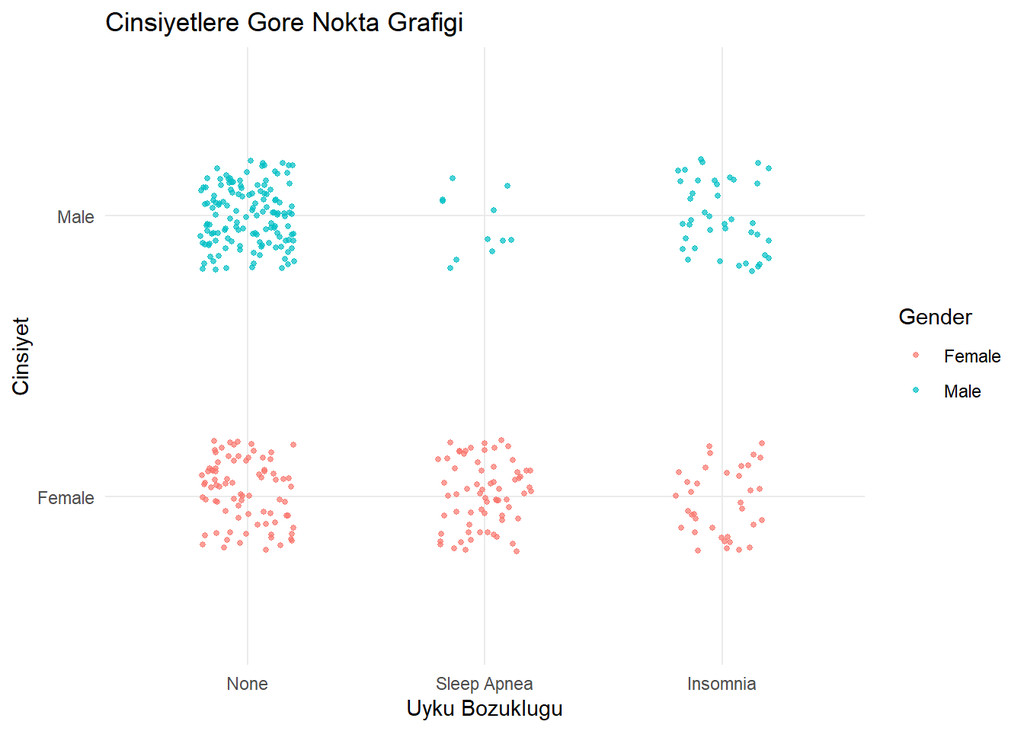

```r
ggplot(sleep, aes(x = Sleep.Disorder, y = Gender, color=Gender)) +
  geom_jitter(width = 0.2, height = 0.2, size = 1, alpha = 0.7) +
  theme_minimal() +
  labs(title = "Cinsiyetlere Gore Nokta Grafigi", x = "Uyku Bozuklugu", y = "Cinsiyet")
```

Bu grafik farklı uyku bozukluklarına sahip bireylerin cinsiyet dağılımının görülebilmesi için yapıldı.

## Sunflower Plot

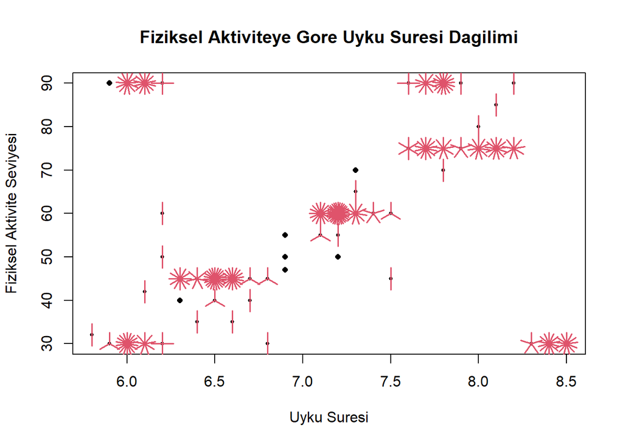

```r
sunflowerplot(sleep$Sleep.Duration, sleep$Physical.Activity.Level,
              main = "Fiziksel Aktiviteye Gore Uyku Suresi Dagilimi",
              xlab = "Uyku Suresi",
              ylab = "Fiziksel Aktivite Seviyesi")
```

Bu grafik uyku süresi ve fiziksel aktivite seviyeleri arasındaki ilişkileri ve hangi kombinasyonların daha yaygın olduğunu anlamak için kullanıldı.

- Bu grafikten genellikle orta düzeyde uyku süresi ve fiziksel aktivite seviyelerinin daha yaygın olduğu söylenebilir.
- 7 ile 7.5 saat uyku süresi ve 60 ila 80 arası fiziksel aktivite seviyeleri etrafında daha fazla gözlem bulunmaktadır.

## Barcode Plot

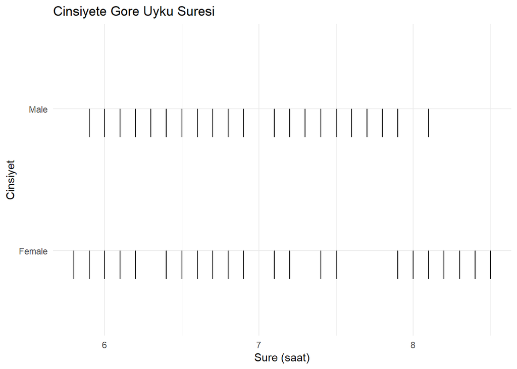

```r
ggplot(sleep, aes(x = Sleep.Duration, y = Gender)) +
  geom_segment(aes(xend = Sleep.Duration, yend = as.numeric(Gender) - 0.2),
               linetype = "solid", size = 0.5) +
  theme_minimal() +
  labs(title = "Cinsiyete Gore Uyku Suresi", x = "Sure (saat)", y = "Cinsiyet")
```

Bu grafik cinsiyetler arasında uyku süresinin nasıl dağıldığını görselleştirmek için elde edildi.

- Erkekler ve kadınlar için uyku süreleri genellikle 6 ile 8 saat arasında yoğunlaşmıştır.
- Hem erkekler hem de kadınlar için uyku süresi dağılımı oldukça benzer görünmektedir.
- Grafik cinsiyetler arasında belirgin bir uyku süresi farkı göstermemektedir.

## Beeswarm Plot

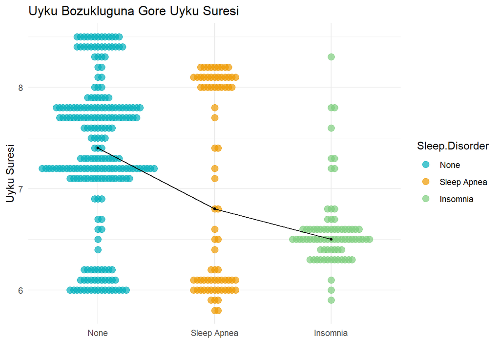

```r
library(ggplot2)
library(ggbeeswarm)
ggplot(sleep, aes(x = Sleep.Disorder, y = Sleep.Duration, color = Sleep.Disorder)) +
  geom_beeswarm(size = 3, alpha = 0.7) +
  stat_summary(fun = median, geom = "point", color = "black", size = 1) +
  stat_summary(fun = median, geom = "line", aes(group = 1), color = "black", size = 0.5) +
  scale_color_manual(values = c("None" = "#00AFBB", "Insomnia" = "palegreen3", "Sleep Apnea" = "orange2")) +
  theme_minimal() +
  labs(title = "Uyku Bozukluguna Gore Uyku Suresi",
       x = "",
       y = "Uyku Suresi")
```

Bu grafik uyku bozukluklarına göre uyku sürelerinin dağılımını göstermek için yapıldı.